# Commissariamenti comunali in Campania: Machine Learning per mappare il rischio

LUCA RUOCCO, ROBERTA FUSCO, GIUSY BRUNO

2025-04-22

## R Markdown

Il presente lavoro di analisi si propone di esplorare e modellizzare i fattori socio-economici, demografici, ambientali e amministrativi associati al rischio di scioglimento dei comuni per infiltrazioni mafiose nella regione Campania.

Il dataset utilizzato raccoglie informazioni eterogenee su 550 comuni campani, con variabili che spaziano dalla composizione demografica alla partecipazione politica, dalle finanze pubbliche ai livelli di criminalità ambientale, passando per indicatori di inclusione sociale e sviluppo economico.

L’obiettivo centrale è duplice:

Analisi descrittiva ed esplorativa per individuare pattern strutturali che differenziano i comuni commissariati da quelli non coinvolti.

Costruzione di modelli predittivi tramite tecniche di machine learning supervisionato, al fine di identificare le caratteristiche più rilevanti nella previsione del rischio di infiltrazione mafiosa.

Per affrontare la sfida dell’alto sbilanciamento della variabile target, sono state adottate strategie di bilanciamento (ROSE), mentre l’affidabilità dei modelli è stata validata tramite cross-validation ripetuta.

Nel corso dell’analisi verranno applicati e confrontati diversi algoritmi: Random Forest, LASSO, Gradient Boosting Machine, Neural Network e Regressione Logistica, valutando le loro performance in termini di AUC ROC, sensibilità e specificità.

```r
# L I B R E R I E
library(readxl)
library(dplyr)
```

```r
library(ggplot2)
library(reshape2)
library(RColorBrewer)
library(patchwork)
library(geodata)
library(terra)
library(sf)
library(skimr)
library(caret)
library(glmnet)
library(pROC)
library(randomForest)
library(gridExtra)
library(ggpubr)
library(ggcorrplot)
library(ROSE)
library(gbm)
# Carica il dataset
df <- read_excel("DATASET PW RESCE.xlsx")

# Sostituisci i "." con NA su tutto il dataframe
df[df == "."] <- NA
```

```r
df$Provincia <- as.factor(df$Provincia)
df$Comune <- as.factor(df$Comune)

df$`Donne % negli organi decisionali per comune _ 2021` <- as.numeric(df$`Donne % negli organi decisionali per comune _ 2021`)
df$`Età media dei consiglieri comunali _ 2021` <- as.numeric(df$`Età media dei consiglieri comunali _ 2021`)


# sostituire i NA con la media per due colonne specifiche
df$`Donne % negli organi decisionali per comune _ 2021`[is.na(df$`Donne % negli organi decisionali per comune _ 2021`)] <-
  mean(df$`Donne % negli organi decisionali per comune _ 2021`, na.rm = TRUE)

df$`Età media dei consiglieri comunali _ 2021`[is.na(df$`Età media dei consiglieri comunali _ 2021`)] <-
  mean(df$`Età media dei consiglieri comunali _ 2021`, na.rm = TRUE)


# Ricodifica dei livelli mantenendo il tipo factor
df$Sciolto_per_Mafia <- factor(df$Sciolto_per_Mafia, levels = c("FALSE", "TRUE"), labels = c("0", "1"))
df$Confinante_sciolto <- factor(df$Confinante_sciolto, levels = c("FALSE", "TRUE"), labels = c("0", "1"))

str(df)
```

```
## tibble [550 × 29] (S3: tbl_df/tbl/data.frame)
##  $ Provincia                                                                     : Factor w/ 5 levels "Avellino","Benevento",..: 5 4 4 4 5 1 3 2 5 5 ...
##  $ Comune                                                                        : Factor w/ 550 levels "Acerno","Acerra",..: 1 2 3 4 5 6 7 8 9 10 ...
##  $ Donne % negli organi decisionali per comune _ 2021                            : num [1:550] 0 33.3 37.5 60 33.3 ...
##  $ Età media dei consiglieri comunali _ 2021                                     : num [1:550] 52.1 42.9 43.6 42.6 55.9 ...
##  $ Partecipazione elettorale _ Triennio(19-21)                                   : num [1:550] 70.4 72.7 65.8 75.3 71.9 ...
##  $ Popolazione residente al 2021                                                 : num [1:550] 2500 58494 62198 7666 21173 ...
##  $ Popolazione straniera residente al 2021                                       : num [1:550] 59 2208 1807 361 1273 ...
##  $ Tasso di occupazione per comune                                               : num [1:550] 39.6 39.2 33.6 40.8 40.1 ...
##  $ Tasso di disoccupazione per comune                                            : num [1:550] 10.7 13.3 15.5 11.2 12.8 ...
##  $ Tasso di inattività per comune                                                : num [1:550] 55.6 54.8 60.3 54 54 ...
##  $ Contribuenti Irpef con reddito complessivo inferiore a 10 mila euro per comune: num [1:550] 52.2 35.1 38.7 41.5 38.5 ...
##  $ Reddito imponibile per contribuente e comune                                  : num [1:550] 11480 16921 15897 14628 17990 ...
##  $ % conseguimento del titolo terziario                                          : num [1:550] 15.9 17.6 14.6 19.5 29.7 ...
##  $ Spesa per interventi e servizi sociali per abitante                           : num [1:550] 55 80.8 54.2 47.2 37.4 ...
##  $ Raccolta differenziata dei rifiuti urbani                                     : num [1:550] 74.5 68 30.5 70.5 61.1 ...
##  $ Autovetture circolanti con standard di emissioni inferiori alla classe Euro 4 : num [1:550] 53.4 41.3 51.2 36.5 38.3 ...
##  $ Consumo di suolo                                                              : num [1:550] 1.87 21.35 44.91 12.7 21.5 ...
##  $ Tasso di imprenditorialità                                                    : num [1:550] 44.1 39.3 44.8 69.9 82.4 ...
##  $ Numero istituzioni non profit per 100.000 abitanti per comune                 : num [1:550] 350 314 184 417 591 ...
##  $ Aziende Sequestrate                                                           : num [1:550] 0 0 5 0 0 1 0 0 0 0 ...
##  $ Beni Immobili Sequestati                                                      : num [1:550] 0 6 90 0 46 2 0 0 0 0 ...
##  $ Eta_Media_Totale_2014-2019_Media                                              : num [1:550] 43.8 37.4 37.9 41.9 43.6 ...
##  $ Totale Entrate                                                                : num [1:550] 7952526 80257397 93185269 11013073 61850862 ...
##  $ Totale Spese                                                                  : num [1:550] 7575848 73271345 80966731 10366671 56437584 ...
##  $ Media Pressione finanziaria per abitante                                      : num [1:550] 677 615 738 581 640 ...
##  $ Siti Contaminati                                                              : num [1:550] 6 1100 971 364 1 194 6 102 3 0 ...
##  $ Superficie (km^2)                                                             : num [1:550] 72.5 54.7 17.9 19.8 32.8 ...
##  $ Confinante_sciolto                                                            : Factor w/ 2 levels "0","1": 1 2 2 2 1 1 1 1 1 1 ...
##  $ Sciolto_per_Mafia                                                             : Factor w/ 2 levels "0","1": 1 2 2 1 1 1 1 1 1 1 ...
```

```r
sum(is.na(df))
```

```
## [1] 0
```

```r
# Controlla la distribuzione della variabile target
table(df$Sciolto_per_Mafia)
```

```
##
##   0   1
## 477  73
```

```r
prop.table(table(df$Sciolto_per_Mafia))
```

```
##
##         0         1
## 0.8672727 0.1327273
```

```r
# DESCRIZIONE DELLE VARIABILI UTILIZZATE

# 1. Seleziona variabili numeriche
num_vars <- df[sapply(df, is.numeric)]

skim(num_vars)
```

Data summary

| Name | num_vars |
| --- | --- |
| Number of rows | 550 |
| Number of columns | 25 |
| _______________________ |  |
| Column type frequency: |  |
| numeric | 25 |
| ________________________ |  |
| Group variables | None |

**Variable type: numeric**

| skim_variable | n_missing | complete_rate | mean | sd | p0 | p25 | p50 | p75 | p100 | hist |
| --- | --- | --- | --- | --- | --- | --- | --- | --- | --- | --- |
| Donne % negli organi decisionali per comune _ 2021 | 0 | 1 | 31.05 | 16.60 | 0.00 | 31.05 | 33.33 | 40.00 | 8.000000e+01 | ▂▁▇▁▁ |
| Età media dei consiglieri comunali _ 2021 | 0 | 1 | 46.33 | 3.98 | 30.80 | 43.62 | 46.33 | 48.74 | 6.089000e+01 | ▁▃▇▃▁ |
| Partecipazione elettorale _ Triennio(19-21) | 0 | 1 | 65.93 | 11.82 | 14.55 | 58.88 | 68.55 | 74.12 | 8.960000e+01 | ▁▁▃▇▃ |
| Popolazione residente al 2021 | 0 | 1 | 10226.22 | 41481.13 | 220.00 | 1464.50 | 3035.50 | 8715.75 | 9.211420e+05 | ▇▁▁▁▁ |
| Popolazione straniera residente al 2021 | 0 | 1 | 436.35 | 2366.65 | 1.00 | 39.25 | 89.50 | 314.00 | 5.344000e+04 | ▇▁▁▁▁ |
| Tasso di occupazione per comune | 0 | 1 | 38.43 | 3.40 | 24.35 | 36.46 | 38.77 | 40.74 | 4.755000e+01 | ▁▁▆▇▁ |
| Tasso di disoccupazione per comune | 0 | 1 | 11.49 | 2.03 | 5.39 | 10.18 | 11.22 | 12.64 | 2.017000e+01 | ▁▇▆▂▁ |
| Tasso di inattività per comune | 0 | 1 | 56.60 | 3.49 | 48.03 | 54.31 | 56.25 | 58.65 | 7.128000e+01 | ▂▇▅▁▁ |
| Contribuenti Irpef con reddito complessivo inferiore a 10 mila euro per comune | 0 | 1 | 40.22 | 5.22 | 27.42 | 36.40 | 39.76 | 43.52 | 5.799000e+01 | ▂▇▇▂▁ |
| Reddito imponibile per contribuente e comune | 0 | 1 | 15705.98 | 2198.98 | 10767.03 | 14280.32 | 15512.04 | 16965.80 | 2.488810e+04 | ▂▇▅▁▁ |
| % conseguimento del titolo terziario | 0 | 1 | 23.13 | 4.89 | 10.83 | 19.63 | 22.97 | 26.35 | 4.345000e+01 | ▂▇▆▁▁ |
| Spesa per interventi e servizi sociali per abitante | 0 | 1 | 49.38 | 45.81 | 0.00 | 28.41 | 45.37 | 63.05 | 6.628500e+02 | ▇▁▁▁▁ |
| Raccolta differenziata dei rifiuti urbani | 0 | 1 | 65.34 | 13.58 | 16.82 | 57.44 | 66.90 | 74.51 | 9.995000e+01 | ▁▂▇▇▁ |
| Autovetture circolanti con standard di emissioni inferiori alla classe Euro 4 | 0 | 1 | 41.18 | 6.34 | 27.17 | 36.84 | 40.79 | 45.29 | 6.426000e+01 | ▃▇▆▂▁ |
| Consumo di suolo | 0 | 1 | 15.61 | 16.17 | 0.72 | 5.45 | 8.83 | 19.23 | 9.112000e+01 | ▇▂▁▁▁ |
| Tasso di imprenditorialità | 0 | 1 | 58.69 | 16.74 | 10.60 | 47.64 | 56.98 | 66.70 | 1.553900e+02 | ▁▇▂▁▁ |
| Numero istituzioni non profit per 100.000 abitanti per comune | 0 | 1 | 382.11 | 168.26 | 0.00 | 271.49 | 361.09 | 470.86 | 1.352370e+03 | ▃▇▂▁▁ |
| Aziende Sequestrate | 0 | 1 | 1.25 | 8.07 | 0.00 | 0.00 | 0.00 | 0.00 | 1.770000e+02 | ▇▁▁▁▁ |
| Beni Immobili Sequestati | 0 | 1 | 8.06 | 36.75 | 0.00 | 0.00 | 0.00 | 2.00 | 6.100000e+02 | ▇▁▁▁▁ |
| Eta_Media_Totale_2014-2019_Media | 0 | 1 | 44.23 | 3.61 | 34.34 | 41.73 | 44.24 | 46.50 | 5.618000e+01 | ▁▆▇▃▁ |
| Totale Entrate | 0 | 1 | 21563420.90 | 157117033.20 | 1281581.64 | 3783820.47 | 6830792.82 | 13741992.50 | 3.631531e+09 | ▇▁▁▁▁ |
| Totale Spese | 0 | 1 | 19678198.93 | 141563694.92 | 1208712.55 | 3590157.55 | 6363536.06 | 13015395.16 | 3.269086e+09 | ▇▁▁▁▁ |
| Media Pressione finanziaria per abitante | 0 | 1 | 588.00 | 161.27 | 92.05 | 532.64 | 618.53 | 690.31 | 8.867300e+02 | ▁▁▃▇▂ |
| Siti Contaminati | 0 | 1 | 168.38 | 251.35 | 0.00 | 2.00 | 8.00 | 305.50 | 1.122000e+03 | ▇▁▁▁▁ |
| Superficie (km^2) | 0 | 1 | 24.86 | 23.82 | 0.12 | 8.68 | 17.78 | 32.35 | 1.867400e+02 | ▇▂▁▁▁ |

#Tendenze generali #Le variabili demografiche e finanziarie mostrano una forte asimmetria positiva, come evidenziato da differenze marcate tra media e mediana #(es. Popolazione residente, Totale Entrate, Totale Spese, Superficie), con valori estremi molto elevati (outlier).

#Le variabili politiche e istituzionali (es. % Donne negli organi decisionali, Età media consiglieri, Partecipazione elettorale) presentano distribuzioni più simmetriche e varianze contenute.

#Alcune variabili mostrano valori massimi estremamente elevati rispetto alle medie, come nel caso di:

# Popolazione residente: media ≈ 10.226, max ≈ 921.142

#Siti Contaminati: media ≈ 168, max ≈ 1.122 Questi dati indicano la presenza di comuni significativamente più grandi o problematici rispetto alla media, #che potrebbero influenzare le analisi se non trattati opportunamente.

```r
# Applichiamo log(x + 1) a variabili con valori alti e outlier evidenti

df$Popolazione_residente_log <- log1p(df$`Popolazione residente al 2021`)
df$Popolazione_straniera_log <- log1p(df$`Popolazione straniera residente al 2021`)
df$Reddito_imponibile_log <- log1p(df$`Reddito imponibile per contribuente e comune`)
df$Totale_Entrate_log <- log1p(df$`Totale Entrate`)
df$Totale_Spese_log <- log1p(df$`Totale Spese`)
df$Istituzioni_non_profit_log <- log1p(df$`Numero istituzioni non profit per 100.000 abitanti per comune`)
df$Aziende_Sequestrate_log <- log1p(df$`Aziende Sequestrate`)
df$Beni_Sequestrati_log <- log1p(df$`Beni Immobili Sequestati`)

# Visualizza le trasformazioni per conferma
summary(df[, c("Popolazione_residente_log", "Popolazione_straniera_log",
               "Reddito_imponibile_log", "Totale_Entrate_log",
               "Totale_Spese_log", "Istituzioni_non_profit_log",
               "Aziende_Sequestrate_log", "Beni_Sequestrati_log")])
```

```
##  Popolazione_residente_log Popolazione_straniera_log Reddito_imponibile_log
##  Min.   : 5.398            Min.   : 0.6931           Min.   : 9.284
##  1st Qu.: 7.290            1st Qu.: 3.6951           1st Qu.: 9.567
##  Median : 8.018            Median : 4.5053           Median : 9.649
##  Mean   : 8.221            Mean   : 4.7690           Mean   : 9.652
##  3rd Qu.: 9.073            3rd Qu.: 5.7526           3rd Qu.: 9.739
##  Max.   :13.733            Max.   :10.8863           Max.   :10.122
##  Totale_Entrate_log Totale_Spese_log Istituzioni_non_profit_log
##  Min.   :14.06      Min.   :14.01    Min.   :0.000
##  1st Qu.:15.15      1st Qu.:15.09    1st Qu.:5.608
##  Median :15.74      Median :15.67    Median :5.892
##  Mean   :15.91      Mean   :15.84    Mean   :5.808
##  3rd Qu.:16.44      3rd Qu.:16.38    3rd Qu.:6.157
##  Max.   :22.01      Max.   :21.91    Max.   :7.210
##  Aziende_Sequestrate_log Beni_Sequestrati_log
##  Min.   :0.0000          Min.   :0.0000
##  1st Qu.:0.0000          1st Qu.:0.0000
##  Median :0.0000          Median :0.0000
##  Mean   :0.3087          Mean   :0.7074
##  3rd Qu.:0.0000          3rd Qu.:1.0986
##  Max.   :5.1818          Max.   :6.4151
```

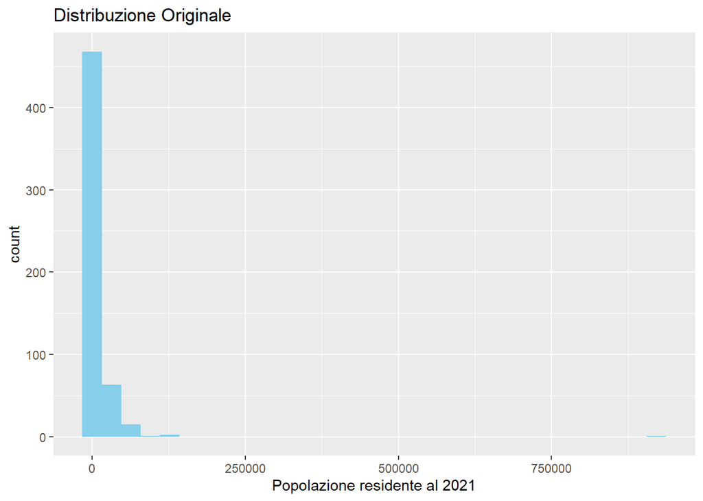

```r
library(ggplot2)

# Esempio: confronto popolazione prima e dopo
ggplot(df, aes(x = `Popolazione residente al 2021`)) +
  geom_histogram(bins = 30, fill = "skyblue") +
  ggtitle("Distribuzione Originale")
```

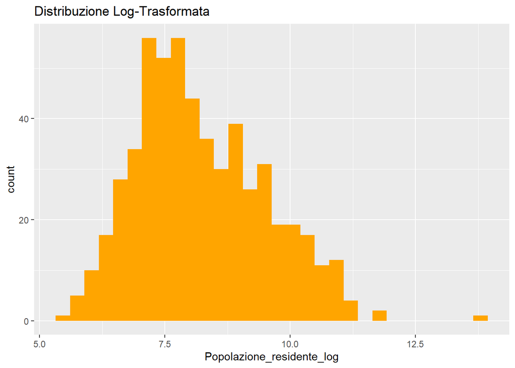

```r
ggplot(df, aes(x = Popolazione_residente_log)) +
  geom_histogram(bins = 30, fill = "orange") +
  ggtitle("Distribuzione Log-Trasformata")
```

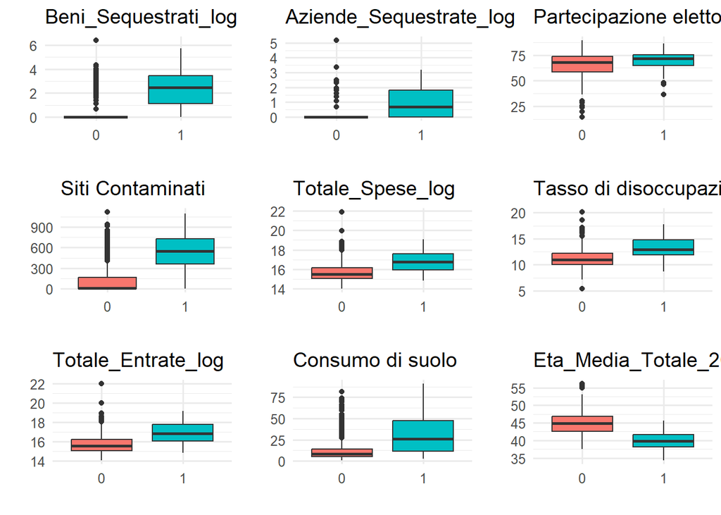

```r
vars <- c(
  "Beni_Sequestrati_log",
  "Aziende_Sequestrate_log",
  "Partecipazione elettorale _ Triennio(19-21)",
  "Siti Contaminati",
  "Totale_Spese_log",
  "Tasso di disoccupazione per comune",
  "Totale_Entrate_log",
  "Consumo di suolo",
  "Eta_Media_Totale_2014-2019_Media"
)

# Genera i boxplot
plots <- lapply(vars, function(var) {
  ggplot(df, aes(x = Sciolto_per_Mafia, y = .data[[var]], fill = Sciolto_per_Mafia)) +
    geom_boxplot() +
    labs(title = var, x = "", y = "") +
    theme_minimal(base_size = 12) +
    theme(legend.position = "none")
})

# Mostra i grafici in una griglia 3x3
ggarrange(plotlist = plots,
          ncol = 3, nrow = 3,
          heights = rep(2, 5), widths = rep(2, 4))
```

L’analisi esplorativa condotta attraverso i boxplot delle principali variabili numeriche rispetto alla variabile binaria Sciolto_per_Mafia (dove 1 indica che il comune è stato sciolto per infiltrazioni mafiose) mette in evidenza alcune differenze interessanti e potenzialmente rilevanti per la successiva fase di modellazione.

Anche il numero di siti contaminati appare significativamente più alto nei comuni a rischio, il che potrebbe essere interpretato come un indicatore indiretto di degrado ambientale o di una gestione territoriale più opaca, fenomeni spesso collegati alla presenza di interessi mafiosi.

Dal punto di vista delle finanze pubbliche, si osserva che i comuni sciolti presentano mediamente spese e entrate più elevate rispetto agli altri. Questo elemento è particolarmente interessante: contrariamente a quanto ci si potrebbe aspettare, non si tratta necessariamente di territori economicamente marginali, ma spesso di realtà con risorse pubbliche consistenti. Ciò potrebbe riflettere un maggiore interesse da parte della criminalità organizzata a infiltrarsi in amministrazioni in cui “vale la pena” gestire appalti e flussi finanziari.

Nel complesso, questi grafici confermano l’esistenza di differenze strutturali tra i comuni sciolti e quelli non sciolti, e forniscono una prima indicazione visiva del potenziale predittivo delle variabili selezionate. Le osservazioni emerse rafforzano l’ipotesi che fattori ambientali, economici e sociali possano costituire segnali anticipatori utili per costruire un modello di previsione del rischio di infiltrazione mafiosa nelle amministrazioni locali.

```r
df <- df[, !names(df) %in% c(
  "Popolazione residente al 2021",
  "Popolazione straniera residente al 2021",
  "Reddito imponibile per contribuente e comune",
  "Totale Entrate",
  "Totale Spese",
  "Numero istituzioni non profit per 100.000 abitanti per comune",
  "Aziende Sequestrate",
  "Beni Immobili Sequestati"
)]
```

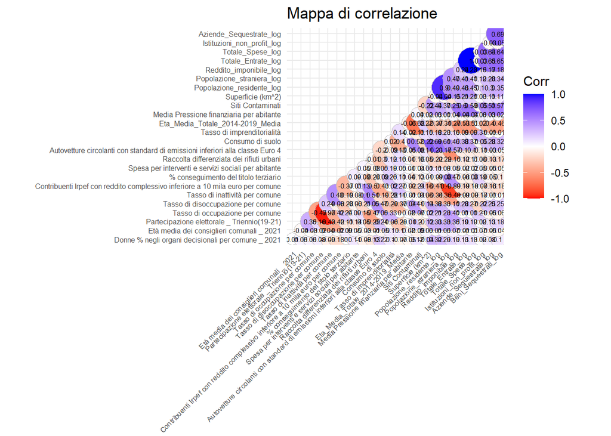

```r
# Seleziona solo le variabili numeriche
df_num <- df[, sapply(df, is.numeric)]

# Calcola la matrice di correlazione
cor_matrix <- cor(df_num, use = "complete.obs")


# Heatmap delle correlazioni
ggcorrplot(cor_matrix,
           method = "circle",        # oppure "square"
           type = "lower",           # solo triangolo inferiore
           lab = TRUE,               # mostra i valori
           lab_size = 2,
           tl.cex = 6,    # testo delle etichette
           colors = c("red", "white", "blue"),
           title = "Mappa di correlazione",
           ggtheme = theme_minimal())
```

# Analisi della correlazione tra variabili numeriche # La heatmap rappresenta la matrice di correlazione di Pearson tra le variabili numeriche considerate nel dataset. #È stata realizzata per identificare eventuali collinearità, ridondanze informative e relazioni strutturali tra le variabili che #potrebbero influenzare il rischio di scioglimento dei comuni per infiltrazioni mafiose.

#Correlazioni positive elevate #Dalla mappa emerge un cluster chiaro di variabili demografiche ed economico-finanziarie fortemente correlate:

#Superficie comunale, popolazione residente, popolazione straniera, entrate, spese e pressione finanziaria mostrano correlazioni positive tra loro. #Questo gruppo indica che i comuni di dimensioni maggiori tendono anche ad avere bilanci più ampi, maggiore densità amministrativa e complessità sociale.

#Anche il numero di siti contaminati si lega a queste variabili, suggerendo che comuni più grandi o urbanizzati siano potenzialmente più esposti a criticità ambientali.

#Correlazioni negative rilevanti #Alcune variabili sociali e istituzionali mostrano correlazioni negative, in particolare:

#La percentuale di donne negli organi decisionali e la partecipazione elettorale tendono a essere debolmente correlate negativamente con #variabili economiche e ambientali, suggerendo una disconnessione tra inclusione politica e contesto territoriale.

#Il tasso di inattività, disoccupazione e quota di contribuenti a basso reddito mostrano invece una debole opposizione rispetto ai principali indicatori di sviluppo.

#Bassa collinearità generale #La maggior parte delle correlazioni si colloca in un range moderato o basso, segno che:

#il dataset mantiene una buona diversità informativa,